# Duodenum Histology Analysis

Chloe J McGovern

2025-10-08

# Duodenum Histology

## Why do you look at the duodenum under the microscope?

It gives us a visual way to see what is happening inside the body. During sample preparation, there can be damage that is done so it is important to note of it is a clinical issue or a methodological limitation.

The duodenum is the first part of the small intestine. In chicks, we find it as a loop with the pancreas in between the two sides. This is important to know because we may see the pancreas depending on how the cross sections are prepared.

When looking under the microscope there are several things we can measure and look for. Starting at the outer most layer (potentially nect to the pancreas) is the mucularis external layer followed by a thick layer of submucosal muscle tissue, followed by a think layer of muscularis mucosae. The top if this later is where the lamina propria begins, and thus the bottom of the crypt depth measurement. This is an important measurement when pared with villi height to determine instestinal homeostasis. It can also be called the invagination site if reading through literature and finding misnomers. The villi are also made of lamina propria and have a more complex physiology but that is for a later time. What matters in this analysis is the villi height, width (taken three times and averaged) and we will alcualte surface area using the equation for a cylinder.

## Staining: What do we use and what do we see?

We used PAS (Periodic Acid Schiff-haematoxylin) staining to highlight the goblet cells. Goblet cells can be pink/magenta for neutral pH’s and dark blue/purple for acidic pH’s. Due to the proximity of the duodenum to the stomach, there tends to be more acidic staining goblet cells most likely because of the acidic nature of the chime leaving the stomach (very acidic). It is important to note that goblet cells themselves are NOT acidic or neutral charged, but rather the mucins they produce are acidic which is where the staining color change happens.

# Objective:

# Load in data and any other necessities

```r
pacman::p_load(tidyverse, ggplot2, dplyr, patchwork, Hmisc,
               lme4, lmerTest, emmeans, car, ggsignif, install = FALSE)

#install.packages("Hmisc")
#install.packages("lme4")
#install.packages("lmerTest")
#install.packages("emmeans")
#install.packages("car")
#install.packages("ggsignif")

#load times new roman font
windowsFonts("Times New Roman" = windowsFont("Times New Roman"))

theme(
    text = element_text(family = "Times New Roman")
)
```

[output not shown]

```r
mix_histo <- read.csv("Data/CSVs/mix-histology-duod.csv")

glimpse(mix_histo)
```

```
## Rows: 350
## Columns: 8
## $ treatment      <int> 1, 1, 1, 1, 1, 1, 1, 1, 1, 1, 1, 1, 1, 1, 1, 1, 1, 1, 1…
## $ biological_rep <int> 1, 1, 1, 1, 1, 1, 1, 1, 1, 1, 2, 2, 2, 2, 2, 2, 2, 2, 2…
## $ villis_height  <dbl> 313.48, 307.81, 318.11, 256.39, 251.99, 273.73, 353.25,…
## $ villis_width1  <dbl> 39.13, 32.24, 26.46, 59.35, 55.78, 33.39, 38.16, 37.83,…
## $ villis_width2  <dbl> 42.79, 27.83, 47.49, 54.84, 65.77, 34.84, 42.07, 40.15,…
## $ villis_width3  <dbl> 42.56, 32.62, 44.59, 48.99, 54.05, 40.19, 40.63, 42.66,…
## $ crypt_depth    <dbl> 12.55, 19.00, 14.47, 10.45, 30.76, 10.39, 24.58, 22.66,…
## $ goblet_count   <int> 64, 88, 38, 65, 47, 67, 37, 61, 55, 38, 33, 44, 43, 38,…
```

```r
source("Code/colors.R")
```

## Prepare column names ahead of time

```r
mix_histo <- mix_histo %>%
  mutate(
    treatment = factor(treatment,
      levels = c("1", "2", "7", "8", "9"),
      labels = c("No Injection", "Water", "Mix Dose 1", "Mix Dose 2", "Mix Dose 3")
    )
  )

#View(mix_histo)
```

# Analysis

## 1. Villi Height

### Height Plain Graph

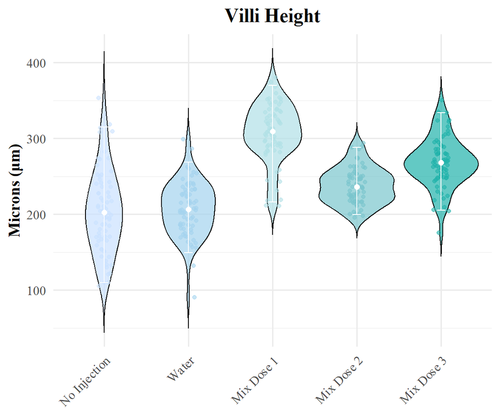

```r
# violin plot to see the distribution

height <- ggplot(mix_histo, aes(x = treatment, y = villis_height, fill = treatment)) +
  # full violin
  geom_violin(trim = FALSE, alpha = 0.7, color = "black") +
  # overlay individual points
  geom_jitter(aes(color = treatment),
              width = 0.1, size = 1.5, alpha = 0.6) +
  # optional: show median + IQR
  stat_summary(fun = median, geom = "point",
               size = 2, color = "white") +
  stat_summary(fun.data = median_hilow, geom = "errorbar",
               width = 0.1, color = "white") +
  # apply your custom palette
  scale_fill_manual(values = treatment_colors) +
  scale_color_manual(values = treatment_colors) +
  # minimal theme + Times New Roman
  theme_minimal(base_size = 14) +
  theme(
    text            = element_text(family = "Times New Roman"),
    axis.text.x     = element_text(angle = 45, hjust = 1),
    plot.title      = element_text(face = "bold", hjust = 0.5),
    axis.title      = element_text(face = "bold"),
    legend.position = "none"
  ) +
  labs(
    title = "Villi Height",
    x     = NULL,
    y     = "Microns (μm)"
  )

height
```

### Height Mixed Model

```r
#model
model_height <- lmer(villis_height ~ treatment + (1|biological_rep), data = mix_histo)
summary(model_height)
```

```
## Linear mixed model fit by REML. t-tests use Satterthwaite's method [
## lmerModLmerTest]
## Formula: villis_height ~ treatment + (1 | biological_rep)
##    Data: mix_histo
##
## REML criterion at convergence: 3499.3
##
## Scaled residuals:
##     Min      1Q  Median      3Q     Max
## -2.6699 -0.5754 -0.0031  0.6444  3.7218
##
## Random effects:
##  Groups         Name        Variance Std.Dev.
##  biological_rep (Intercept)  125.3   11.20
##  Residual                   1357.7   36.85
## Number of obs: 350, groups:  biological_rep, 7
##
## Fixed effects:
##                     Estimate Std. Error      df t value Pr(>|t|)
## (Intercept)          204.145      6.107  17.436  33.426  < 2e-16 ***
## treatmentWater         2.903      6.228 339.000   0.466    0.641
## treatmentMix Dose 1  103.327      6.228 339.000  16.590  < 2e-16 ***
## treatmentMix Dose 2   33.531      6.228 339.000   5.384 1.37e-07 ***
## treatmentMix Dose 3   64.049      6.228 339.000  10.284  < 2e-16 ***
## ---
## Signif. codes:  0 '***' 0.001 '**' 0.01 '*' 0.05 '.' 0.1 ' ' 1
##
## Correlation of Fixed Effects:
##             (Intr) trtmnW trtMD1 trtMD2
## treatmntWtr -0.510
## trtmntMxDs1 -0.510  0.500
## trtmntMxDs2 -0.510  0.500  0.500
## trtmntMxDs3 -0.510  0.500  0.500  0.500
```

```r
#post hoc
post_hoc_height <- emmeans(model_height, pairwise ~ treatment)
summary(post_hoc_height)
```

```
## $emmeans
##  treatment    emmean   SE   df lower.CL upper.CL
##  No Injection    204 6.11 17.4      191      217
##  Water           207 6.11 17.4      194      220
##  Mix Dose 1      307 6.11 17.4      295      320
##  Mix Dose 2      238 6.11 17.4      225      251
##  Mix Dose 3      268 6.11 17.4      255      281
##
## Degrees-of-freedom method: kenward-roger
## Confidence level used: 0.95
##
## $contrasts
##  contrast                  estimate   SE  df t.ratio p.value
##  No Injection - Water          -2.9 6.23 339  -0.466  0.9903
##  No Injection - Mix Dose 1   -103.3 6.23 339 -16.590  <.0001
##  No Injection - Mix Dose 2    -33.5 6.23 339  -5.384  <.0001
##  No Injection - Mix Dose 3    -64.0 6.23 339 -10.284  <.0001
##  Water - Mix Dose 1          -100.4 6.23 339 -16.124  <.0001
##  Water - Mix Dose 2           -30.6 6.23 339  -4.918  <.0001
##  Water - Mix Dose 3           -61.1 6.23 339  -9.818  <.0001
##  Mix Dose 1 - Mix Dose 2       69.8 6.23 339  11.206  <.0001
##  Mix Dose 1 - Mix Dose 3       39.3 6.23 339   6.306  <.0001
##  Mix Dose 2 - Mix Dose 3      -30.5 6.23 339  -4.900  <.0001
##
## Degrees-of-freedom method: kenward-roger
## P value adjustment: tukey method for comparing a family of 5 estimates
```

```r
# Extract p-values for the pairwise comparisons
p_height <- as.data.frame(post_hoc_height$contrasts)
p_height
```

```
##  contrast                    estimate       SE  df t.ratio p.value
##  No Injection - Water        -2.90286 6.228301 339  -0.466  0.9903
##  No Injection - Mix Dose 1 -103.32700 6.228301 339 -16.590  <.0001
##  No Injection - Mix Dose 2  -33.53143 6.228301 339  -5.384  <.0001
##  No Injection - Mix Dose 3  -64.04943 6.228301 339 -10.284  <.0001
##  Water - Mix Dose 1        -100.42414 6.228301 339 -16.124  <.0001
##  Water - Mix Dose 2         -30.62857 6.228301 339  -4.918  <.0001
##  Water - Mix Dose 3         -61.14657 6.228301 339  -9.818  <.0001
##  Mix Dose 1 - Mix Dose 2     69.79557 6.228301 339  11.206  <.0001
##  Mix Dose 1 - Mix Dose 3     39.27757 6.228301 339   6.306  <.0001
##  Mix Dose 2 - Mix Dose 3    -30.51800 6.228301 339  -4.900  <.0001
##
## Degrees-of-freedom method: kenward-roger
## P value adjustment: tukey method for comparing a family of 5 estimates
```

```r
# Filter for significant p-values (adjust the threshold as needed, e.g., p < 0.05)
significant_p_height <- p_height[p_height$p.value < 0.05, ]
significant_p_height
```

```
##  contrast                    estimate       SE  df t.ratio p.value
##  No Injection - Mix Dose 1 -103.32700 6.228301 339 -16.590  <.0001
##  No Injection - Mix Dose 2  -33.53143 6.228301 339  -5.384  <.0001
##  No Injection - Mix Dose 3  -64.04943 6.228301 339 -10.284  <.0001
##  Water - Mix Dose 1        -100.42414 6.228301 339 -16.124  <.0001
##  Water - Mix Dose 2         -30.62857 6.228301 339  -4.918  <.0001
##  Water - Mix Dose 3         -61.14657 6.228301 339  -9.818  <.0001
##  Mix Dose 1 - Mix Dose 2     69.79557 6.228301 339  11.206  <.0001
##  Mix Dose 1 - Mix Dose 3     39.27757 6.228301 339   6.306  <.0001
##  Mix Dose 2 - Mix Dose 3    -30.51800 6.228301 339  -4.900  <.0001
##
## Degrees-of-freedom method: kenward-roger
## P value adjustment: tukey method for comparing a family of 5 estimates
```

### Height Significant Graph

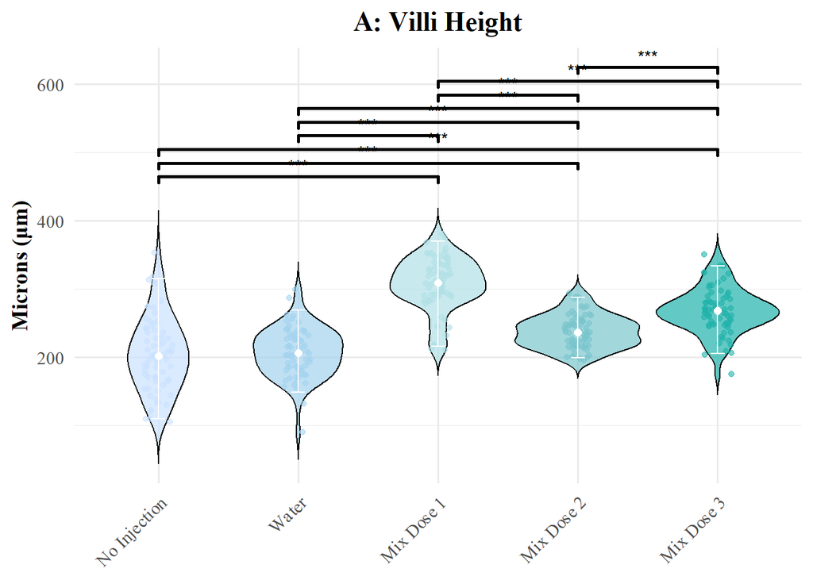

```r
p_height <- ggplot(mix_histo, aes(x = treatment, y = villis_height, fill = treatment)) +
  # full violin
  geom_violin(trim = FALSE, alpha = 0.7, color = "black") +
  # overlay individual points
  geom_jitter(aes(color = treatment),
              width = 0.1, size = 1.5, alpha = 0.6) +
  # optional: show median + IQR
  stat_summary(fun = median, geom = "point",
               size = 2, color = "white") +
  stat_summary(fun.data = median_hilow, geom = "errorbar",
               width = 0.1, color = "white") +
  # apply your custom palette
  scale_fill_manual(values = treatment_colors) +
  scale_color_manual(values = treatment_colors) +
  # minimal theme + Times New Roman
  theme_minimal(base_size = 14) +
  theme(
    text            = element_text(family = "Times New Roman"),
    axis.text.x     = element_text(angle = 45, hjust = 1),
    plot.title      = element_text(face = "bold", hjust = 0.5),
    axis.title      = element_text(face = "bold"),
    legend.position = "none"
  ) +
  labs(
    title = "A: Villi Height",
    x     = NULL,
    y     = "Microns (μm)"
  ) +
  # Add p-value annotations with larger and spaced lines
  geom_signif(
    comparisons = list(
      c("No Injection", "Mix Dose 1"),
      c("No Injection", "Mix Dose 2"),
      c("No Injection", "Mix Dose 3"),
      c("Water", "Mix Dose 1"),
      c("Water", "Mix Dose 2"),
      c("Water", "Mix Dose 3"),
      c("Mix Dose 1", "Mix Dose 2"),
      c("Mix Dose 1", "Mix Dose 3"),
      c("Mix Dose 2", "Mix Dose 3")),  # Define treatment pairs
    map_signif_level = TRUE,  # Automatically adds p-values
    size = 1,  # Increase the size of the lines for better visibility
    y_position = c(450, 470, 490, 510, 530, 550, 570, 590, 610)  # Adjust this to position lines further apart
  )

# Show the updated plot
p_height
```

### Summary of Villi Height

## 2. Villi Width

### Average Widths and Make New Column

```r
mix_histo <-
  mix_histo %>%
   mutate(
    width_avg = rowMeans(select(., villis_width1, villis_width2, villis_width3),
                         na.rm = TRUE)
  )

#View(mix_histo)
```

### Villi Width No Significance

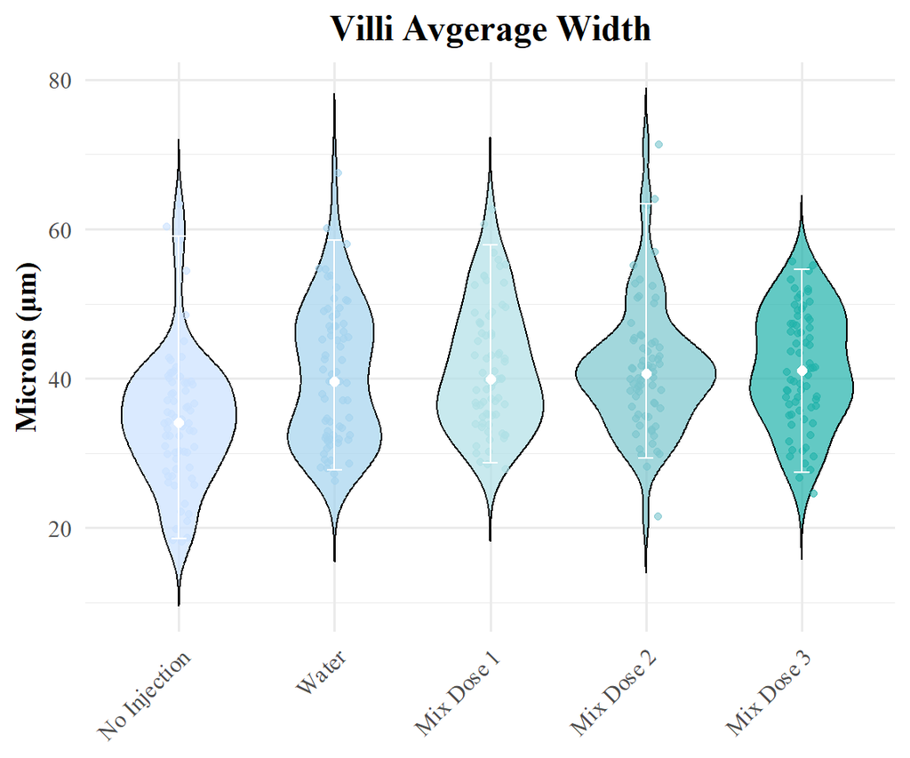

```r
# violin plot to see the distribution

width <- ggplot(mix_histo, aes(x = treatment, y = width_avg, fill = treatment)) +
  # full violin
  geom_violin(trim = FALSE, alpha = 0.7, color = "black") +
  # overlay individual points
  geom_jitter(aes(color = treatment),
              width = 0.1, size = 1.5, alpha = 0.6) +
  # optional: show median + IQR
  stat_summary(fun = median, geom = "point",
               size = 2, color = "white") +
  stat_summary(fun.data = median_hilow, geom = "errorbar",
               width = 0.1, color = "white") +
  # apply your custom palette
  scale_fill_manual(values = treatment_colors) +
  scale_color_manual(values = treatment_colors) +
  # minimal theme + Times New Roman
  theme_minimal(base_size = 14) +
  theme(
    text            = element_text(family = "Times New Roman"),
    axis.text.x     = element_text(angle = 45, hjust = 1),
    plot.title      = element_text(face = "bold", hjust = 0.5),
    axis.title      = element_text(face = "bold"),
    legend.position = "none"
  ) +
  labs(
    title = "Villi Avgerage Width",
    x     = NULL,
    y     = "Microns (μm)"
  )

width
```

### Width Linear Mixed Model

```r
#model
model_width <- lmer(width_avg ~ treatment + (1|biological_rep), data = mix_histo)
summary(model_width)
```

```
## Linear mixed model fit by REML. t-tests use Satterthwaite's method [
## lmerModLmerTest]
## Formula: width_avg ~ treatment + (1 | biological_rep)
##    Data: mix_histo
##
## REML criterion at convergence: 2483.3
##
## Scaled residuals:
##     Min      1Q  Median      3Q     Max
## -2.4509 -0.7136 -0.1015  0.6055  3.8788
##
## Random effects:
##  Groups         Name        Variance Std.Dev.
##  biological_rep (Intercept)  3.268   1.808
##  Residual                   72.094   8.491
## Number of obs: 350, groups:  biological_rep, 7
##
## Fixed effects:
##                     Estimate Std. Error      df t value Pr(>|t|)
## (Intercept)           34.630      1.223  28.924  28.306  < 2e-16 ***
## treatmentWater         5.851      1.435 339.000   4.077 5.70e-05 ***
## treatmentMix Dose 1    6.800      1.435 339.000   4.738 3.18e-06 ***
## treatmentMix Dose 2    6.767      1.435 339.000   4.715 3.53e-06 ***
## treatmentMix Dose 3    6.660      1.435 339.000   4.640 4.98e-06 ***
## ---
## Signif. codes:  0 '***' 0.001 '**' 0.01 '*' 0.05 '.' 0.1 ' ' 1
##
## Correlation of Fixed Effects:
##             (Intr) trtmnW trtMD1 trtMD2
## treatmntWtr -0.587
## trtmntMxDs1 -0.587  0.500
## trtmntMxDs2 -0.587  0.500  0.500
## trtmntMxDs3 -0.587  0.500  0.500  0.500
```

```r
#post hoc
post_hoc_width <- emmeans(model_width, pairwise ~ treatment)
summary(post_hoc_width)
```

```
## $emmeans
##  treatment    emmean   SE   df lower.CL upper.CL
##  No Injection   34.6 1.22 28.9     32.1     37.1
##  Water          40.5 1.22 28.9     38.0     43.0
##  Mix Dose 1     41.4 1.22 28.9     38.9     43.9
##  Mix Dose 2     41.4 1.22 28.9     38.9     43.9
##  Mix Dose 3     41.3 1.22 28.9     38.8     43.8
##
## Degrees-of-freedom method: kenward-roger
## Confidence level used: 0.95
##
## $contrasts
##  contrast                  estimate   SE  df t.ratio p.value
##  No Injection - Water       -5.8510 1.44 339  -4.077  0.0005
##  No Injection - Mix Dose 1  -6.7997 1.44 339  -4.738  <.0001
##  No Injection - Mix Dose 2  -6.7675 1.44 339  -4.715  <.0001
##  No Injection - Mix Dose 3  -6.6599 1.44 339  -4.640  <.0001
##  Water - Mix Dose 1         -0.9487 1.44 339  -0.661  0.9645
##  Water - Mix Dose 2         -0.9165 1.44 339  -0.639  0.9686
##  Water - Mix Dose 3         -0.8090 1.44 339  -0.564  0.9802
##  Mix Dose 1 - Mix Dose 2     0.0322 1.44 339   0.022  1.0000
##  Mix Dose 1 - Mix Dose 3     0.1398 1.44 339   0.097  1.0000
##  Mix Dose 2 - Mix Dose 3     0.1076 1.44 339   0.075  1.0000
##
## Degrees-of-freedom method: kenward-roger
## P value adjustment: tukey method for comparing a family of 5 estimates
```

```r
# Extract p-values for the pairwise comparisons
p_width <- as.data.frame(post_hoc_width$contrasts)
p_width
```

```
##  contrast                   estimate       SE  df t.ratio p.value
##  No Injection - Water      -5.850952 1.435208 339  -4.077  0.0005
##  No Injection - Mix Dose 1 -6.799667 1.435208 339  -4.738  <.0001
##  No Injection - Mix Dose 2 -6.767476 1.435208 339  -4.715  <.0001
##  No Injection - Mix Dose 3 -6.659905 1.435208 339  -4.640  <.0001
##  Water - Mix Dose 1        -0.948714 1.435208 339  -0.661  0.9645
##  Water - Mix Dose 2        -0.916524 1.435208 339  -0.639  0.9686
##  Water - Mix Dose 3        -0.808952 1.435208 339  -0.564  0.9802
##  Mix Dose 1 - Mix Dose 2    0.032190 1.435208 339   0.022  1.0000
##  Mix Dose 1 - Mix Dose 3    0.139762 1.435208 339   0.097  1.0000
##  Mix Dose 2 - Mix Dose 3    0.107571 1.435208 339   0.075  1.0000
##
## Degrees-of-freedom method: kenward-roger
## P value adjustment: tukey method for comparing a family of 5 estimates
```

```r
# Filter for significant p-values (adjust the threshold as needed, e.g., p < 0.05)
significant_p_width <- p_width[p_width$p.value < 0.05, ]
significant_p_width
```

```
##  contrast                   estimate       SE  df t.ratio p.value
##  No Injection - Water      -5.850952 1.435208 339  -4.077  0.0005
##  No Injection - Mix Dose 1 -6.799667 1.435208 339  -4.738  <.0001
##  No Injection - Mix Dose 2 -6.767476 1.435208 339  -4.715  <.0001
##  No Injection - Mix Dose 3 -6.659905 1.435208 339  -4.640  <.0001
##
## Degrees-of-freedom method: kenward-roger
## P value adjustment: tukey method for comparing a family of 5 estimates
```

### Width Plot with Significant P Values

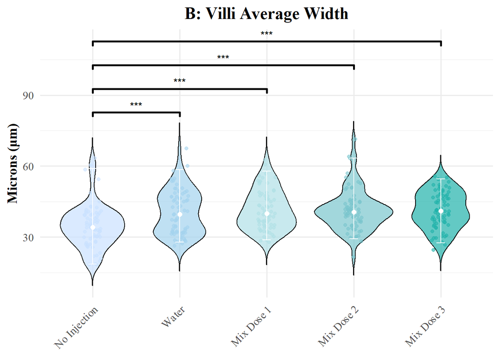

```r
p_width <- ggplot(mix_histo, aes(x = treatment, y = width_avg, fill = treatment)) +
  # full violin
  geom_violin(trim = FALSE, alpha = 0.7, color = "black") +
  # overlay individual points
  geom_jitter(aes(color = treatment),
              width = 0.1, size = 1.5, alpha = 0.6) +
  # optional: show median + IQR
  stat_summary(fun = median, geom = "point",
               size = 2, color = "white") +
  stat_summary(fun.data = median_hilow, geom = "errorbar",
               width = 0.1, color = "white") +
  # apply your custom palette
  scale_fill_manual(values = treatment_colors) +
  scale_color_manual(values = treatment_colors) +
  # minimal theme + Times New Roman
  theme_minimal(base_size = 14) +
  theme(
    text            = element_text(family = "Times New Roman"),
    axis.text.x     = element_text(angle = 45, hjust = 1),
    plot.title      = element_text(face = "bold", hjust = 0.5),
    axis.title      = element_text(face = "bold"),
    legend.position = "none"
  ) +
  labs(
    title = "B: Villi Average Width",
    x     = NULL,
    y     = "Microns (μm)"
  ) +
  # Add p-value annotations with larger and spaced lines
  geom_signif(
    comparisons = list(
      c("No Injection", "Water"),
      c("No Injection", "Mix Dose 1"),
      c("No Injection", "Mix Dose 2"),
      c("No Injection", "Mix Dose 3")),  # Define treatment pairs
    map_signif_level = TRUE,  # Automatically adds p-values
    size = 1,  # Increase the size of the lines for better visibility
    y_position = c(80, 90, 100, 110)  # Adjust this to position lines further apart
  )

# Show the updated plot
p_width
```

### Summary Villi Width

## 3. Villus Surface Area

### Calculate Surface Area and Make New Column

```r
# check
nrow(mix_histo)
```

```
## [1] 350
```

```r
# should be 350

colnames(mix_histo)
```

```
## [1] "treatment"      "biological_rep" "villis_height"  "villis_width1"
## [5] "villis_width2"  "villis_width3"  "crypt_depth"    "goblet_count"
## [9] "width_avg"
```

```r
# make sure you see "width_avg" and "height" in the names


mix_histo <-
  mix_histo %>%
  mutate(
     radius = width_avg / 2,
    surface_area = pi * radius^2   # top + bottom
                 + 2 * pi * radius * villis_height  # lateral
  )

#View(mix_histo)
```

### Surface Area Violin Plot No Significance

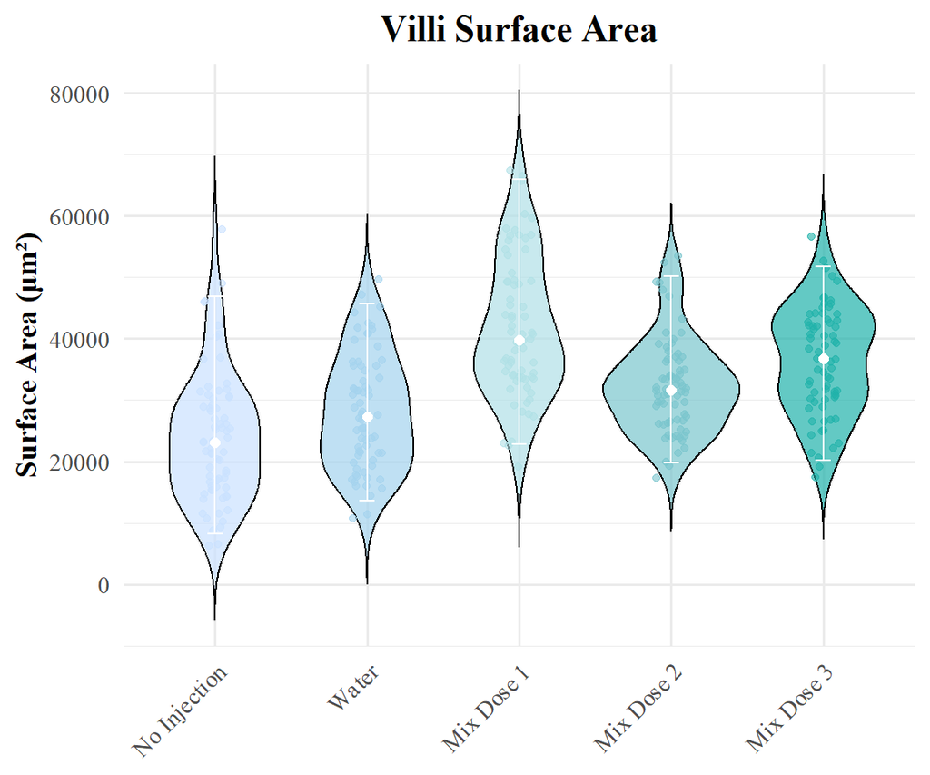

```r
# violin plot to see the distribution

surface_area <- ggplot(mix_histo, aes(x = treatment, y = surface_area, fill = treatment)) +
  # full violin
  geom_violin(trim = FALSE, alpha = 0.7, color = "black") +
  # overlay individual points
  geom_jitter(aes(color = treatment),
              width = 0.1, size = 1.5, alpha = 0.6) +
  # optional: show median + IQR
  stat_summary(fun = median, geom = "point",
               size = 2, color = "white") +
  stat_summary(fun.data = median_hilow, geom = "errorbar",
               width = 0.1, color = "white") +
  # apply your custom palette
  scale_fill_manual(values = treatment_colors) +
  scale_color_manual(values = treatment_colors) +
  # minimal theme + Times New Roman
  theme_minimal(base_size = 14) +
  theme(
    text            = element_text(family = "Times New Roman"),
    axis.text.x     = element_text(angle = 45, hjust = 1),
    plot.title      = element_text(face = "bold", hjust = 0.5),
    axis.title      = element_text(face = "bold"),
    legend.position = "none"
  ) +
  labs(
    title = "Villi Surface Area",
    x     = NULL,
    y     = "Surface Area (μm²)"
  )

surface_area
```

### Run Mixed Model on Surface Area

```r
#model
model_SA <- lmer(surface_area ~ treatment + (1|biological_rep), data = mix_histo)
summary(model_SA)
```

```
## Linear mixed model fit by REML. t-tests use Satterthwaite's method [
## lmerModLmerTest]
## Formula: surface_area ~ treatment + (1 | biological_rep)
##    Data: mix_histo
##
## REML criterion at convergence: 7313.4
##
## Scaled residuals:
##     Min      1Q  Median      3Q     Max
## -2.3863 -0.7337 -0.0586  0.6038  3.3753
##
## Random effects:
##  Groups         Name        Variance Std.Dev.
##  biological_rep (Intercept)  8397927 2898
##  Residual                   85844989 9265
## Number of obs: 350, groups:  biological_rep, 7
##
## Fixed effects:
##                     Estimate Std. Error       df t value Pr(>|t|)
## (Intercept)         23898.26    1557.58    16.78  15.343 2.65e-11 ***
## treatmentWater       4198.64    1566.11   339.00   2.681   0.0077 **
## treatmentMix Dose 1 17864.43    1566.11   339.00  11.407  < 2e-16 ***
## treatmentMix Dose 2  8451.21    1566.11   339.00   5.396 1.28e-07 ***
## treatmentMix Dose 3 12448.58    1566.11   339.00   7.949 2.83e-14 ***
## ---
## Signif. codes:  0 '***' 0.001 '**' 0.01 '*' 0.05 '.' 0.1 ' ' 1
##
## Correlation of Fixed Effects:
##             (Intr) trtmnW trtMD1 trtMD2
## treatmntWtr -0.503
## trtmntMxDs1 -0.503  0.500
## trtmntMxDs2 -0.503  0.500  0.500
## trtmntMxDs3 -0.503  0.500  0.500  0.500
```

```r
#post hoc
post_hoc_SA <- emmeans(model_SA, pairwise ~ treatment)
summary(post_hoc_SA)
```

```
## $emmeans
##  treatment    emmean   SE   df lower.CL upper.CL
##  No Injection  23898 1560 16.8    20609    27188
##  Water         28097 1560 16.8    24807    31386
##  Mix Dose 1    41763 1560 16.8    38473    45052
##  Mix Dose 2    32349 1560 16.8    29060    35639
##  Mix Dose 3    36347 1560 16.8    33057    39636
##
## Degrees-of-freedom method: kenward-roger
## Confidence level used: 0.95
##
## $contrasts
##  contrast                  estimate   SE  df t.ratio p.value
##  No Injection - Water         -4199 1570 339  -2.681  0.0589
##  No Injection - Mix Dose 1   -17864 1570 339 -11.407  <.0001
##  No Injection - Mix Dose 2    -8451 1570 339  -5.396  <.0001
##  No Injection - Mix Dose 3   -12449 1570 339  -7.949  <.0001
##  Water - Mix Dose 1          -13666 1570 339  -8.726  <.0001
##  Water - Mix Dose 2           -4253 1570 339  -2.715  0.0538
##  Water - Mix Dose 3           -8250 1570 339  -5.268  <.0001
##  Mix Dose 1 - Mix Dose 2       9413 1570 339   6.011  <.0001
##  Mix Dose 1 - Mix Dose 3       5416 1570 339   3.458  0.0055
##  Mix Dose 2 - Mix Dose 3      -3997 1570 339  -2.552  0.0818
##
## Degrees-of-freedom method: kenward-roger
## P value adjustment: tukey method for comparing a family of 5 estimates
```

```r
# Extract p-values for the pairwise comparisons
p_SA <- as.data.frame(post_hoc_SA$contrasts)
p_SA
```

```
##  contrast                    estimate       SE  df t.ratio p.value
##  No Injection - Water       -4198.638 1566.114 339  -2.681  0.0589
##  No Injection - Mix Dose 1 -17864.432 1566.114 339 -11.407  <.0001
##  No Injection - Mix Dose 2  -8451.213 1566.114 339  -5.396  <.0001
##  No Injection - Mix Dose 3 -12448.578 1566.114 339  -7.949  <.0001
##  Water - Mix Dose 1        -13665.794 1566.114 339  -8.726  <.0001
##  Water - Mix Dose 2         -4252.575 1566.114 339  -2.715  0.0538
##  Water - Mix Dose 3         -8249.939 1566.114 339  -5.268  <.0001
##  Mix Dose 1 - Mix Dose 2     9413.219 1566.114 339   6.011  <.0001
##  Mix Dose 1 - Mix Dose 3     5415.854 1566.114 339   3.458  0.0055
##  Mix Dose 2 - Mix Dose 3    -3997.365 1566.114 339  -2.552  0.0818
##
## Degrees-of-freedom method: kenward-roger
## P value adjustment: tukey method for comparing a family of 5 estimates
```

```r
# Filter for significant p-values (adjust the threshold as needed, e.g., p < 0.05)
significant_p_SA <- p_SA[p_SA$p.value < 0.05, ]
significant_p_SA
```

```
##  contrast                    estimate       SE  df t.ratio p.value
##  No Injection - Mix Dose 1 -17864.432 1566.114 339 -11.407  <.0001
##  No Injection - Mix Dose 2  -8451.213 1566.114 339  -5.396  <.0001
##  No Injection - Mix Dose 3 -12448.578 1566.114 339  -7.949  <.0001
##  Water - Mix Dose 1        -13665.794 1566.114 339  -8.726  <.0001
##  Water - Mix Dose 3         -8249.939 1566.114 339  -5.268  <.0001
##  Mix Dose 1 - Mix Dose 2     9413.219 1566.114 339   6.011  <.0001
##  Mix Dose 1 - Mix Dose 3     5415.854 1566.114 339   3.458  0.0055
##
## Degrees-of-freedom method: kenward-roger
## P value adjustment: tukey method for comparing a family of 5 estimates
```

### Violin Plot Suface Area with Significance

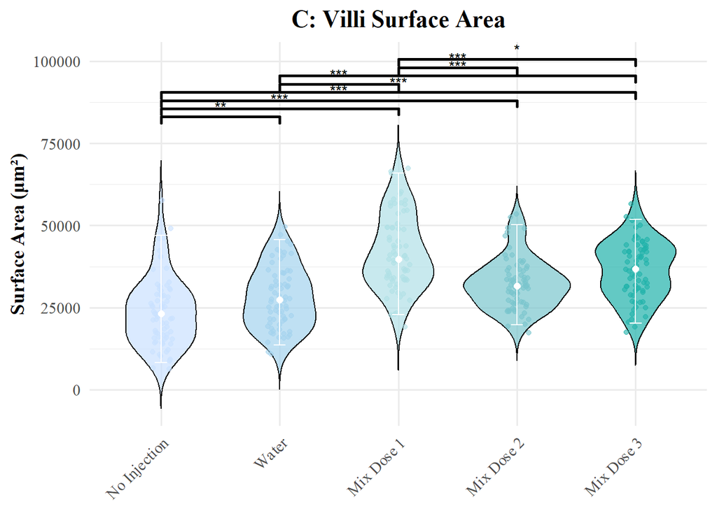

```r
p_SA <- ggplot(mix_histo, aes(x = treatment, y = surface_area, fill = treatment)) +
  # full violin
  geom_violin(trim = FALSE, alpha = 0.7, color = "black") +
  # overlay individual points
  geom_jitter(aes(color = treatment),
              width = 0.1, size = 1.5, alpha = 0.6) +
  # optional: show median + IQR
  stat_summary(fun = median, geom = "point",
               size = 2, color = "white") +
  stat_summary(fun.data = median_hilow, geom = "errorbar",
               width = 0.1, color = "white") +
  # apply your custom palette
  scale_fill_manual(values = treatment_colors) +
  scale_color_manual(values = treatment_colors) +
  # minimal theme + Times New Roman
  theme_minimal(base_size = 14) +
  theme(
    text            = element_text(family = "Times New Roman"),
    axis.text.x     = element_text(angle = 45, hjust = 1),
    plot.title      = element_text(face = "bold", hjust = 0.5),
    axis.title      = element_text(face = "bold"),
    legend.position = "none"
  ) +
  labs(
    title = "C: Villi Surface Area",
    x     = NULL,
    y     = "Surface Area (μm²)"
  ) +
  # Add p-value annotations with larger and spaced lines
  geom_signif(
    comparisons = list(
      c("No Injection", "Water"),
      c("No Injection", "Mix Dose 1"),
      c("No Injection", "Mix Dose 2"),
      c("No Injection", "Mix Dose 3"),
      c("Water", "Mix Dose 1"),
      c("Water", "Mix Dose 3"),
      c("Mix Dose 1", "Mix Dose 2"),
      c("Mix Dose 1", "Mix Dose 3")),  # Define treatment pairs
    map_signif_level = TRUE,  # Automatically adds p-values
    size = 1,  # Increase the size of the lines for better visibility
    y_position = c(80000, 82500, 85000, 87500, 90000, 92500, 95000, 97500)  # Adjust this to position lines further apart
  )

# Show the updated plot
p_SA
```

### Summary Surface Area

## 4. Crypt Depth

### Crypt Depth on Violin Plot

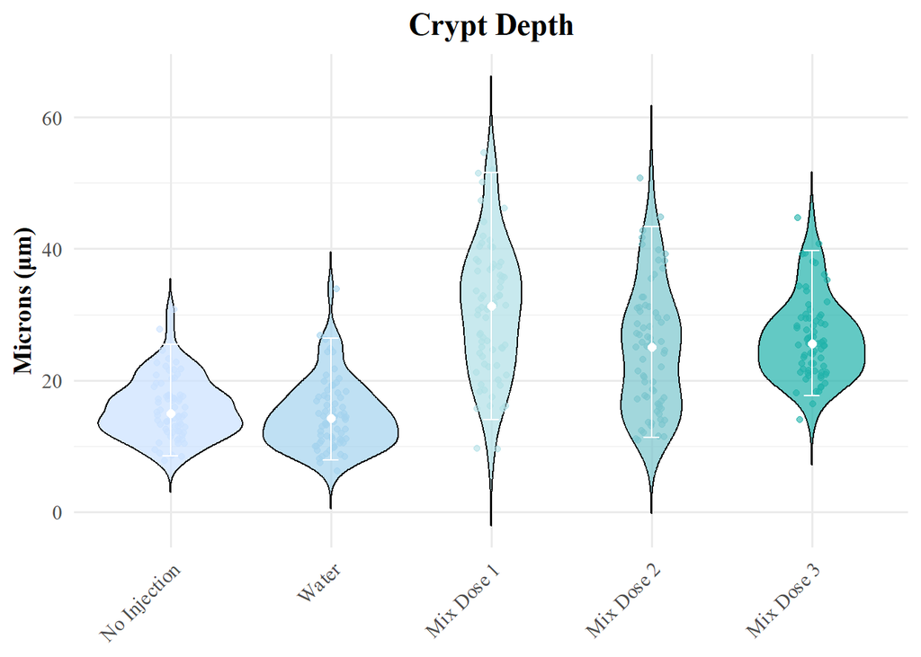

```r
crypt <- ggplot(mix_histo, aes(x = treatment, y = crypt_depth, fill = treatment)) +
  # full violin
  geom_violin(trim = FALSE, alpha = 0.7, color = "black") +
  # overlay individual points
  geom_jitter(aes(color = treatment),
              width = 0.1, size = 1.5, alpha = 0.6) +
  # optional: show median + IQR
  stat_summary(fun = median, geom = "point",
               size = 2, color = "white") +
  stat_summary(fun.data = median_hilow, geom = "errorbar",
               width = 0.1, color = "white") +
  # apply your custom palette
  scale_fill_manual(values = treatment_colors) +
  scale_color_manual(values = treatment_colors) +
  # minimal theme + Times New Roman
  theme_minimal(base_size = 14) +
  theme(
    text            = element_text(family = "Times New Roman"),
    axis.text.x     = element_text(angle = 45, hjust = 1),
    plot.title      = element_text(face = "bold", hjust = 0.5),
    axis.title      = element_text(face = "bold"),
    legend.position = "none"
  ) +
  labs(
    title = "Crypt Depth",
    x     = NULL,
    y     = "Microns (μm)"
  )

crypt
```

### Linear Mixed Model for Crypt Depth

```r
#model
model_crypt <- lmer(crypt_depth ~ treatment + (1|biological_rep), data = mix_histo)
summary(model_crypt)
```

```
## Linear mixed model fit by REML. t-tests use Satterthwaite's method [
## lmerModLmerTest]
## Formula: crypt_depth ~ treatment + (1 | biological_rep)
##    Data: mix_histo
##
## REML criterion at convergence: 2385.7
##
## Scaled residuals:
##     Min      1Q  Median      3Q     Max
## -2.5364 -0.6397 -0.0867  0.6033  3.5136
##
## Random effects:
##  Groups         Name        Variance Std.Dev.
##  biological_rep (Intercept)  2.595   1.611
##  Residual                   54.286   7.368
## Number of obs: 350, groups:  biological_rep, 7
##
## Fixed effects:
##                     Estimate Std. Error      df t value Pr(>|t|)
## (Intercept)           15.850      1.071  27.823  14.804 1.02e-14 ***
## treatmentWater        -1.147      1.245 339.000  -0.921    0.358
## treatmentMix Dose 1   14.898      1.245 339.000  11.963  < 2e-16 ***
## treatmentMix Dose 2    8.893      1.245 339.000   7.141 5.70e-12 ***
## treatmentMix Dose 3   10.563      1.245 339.000   8.482 6.96e-16 ***
## ---
## Signif. codes:  0 '***' 0.001 '**' 0.01 '*' 0.05 '.' 0.1 ' ' 1
##
## Correlation of Fixed Effects:
##             (Intr) trtmnW trtMD1 trtMD2
## treatmntWtr -0.582
## trtmntMxDs1 -0.582  0.500
## trtmntMxDs2 -0.582  0.500  0.500
## trtmntMxDs3 -0.582  0.500  0.500  0.500
```

```r
#post hoc
post_hoc_crypt <- emmeans(model_crypt, pairwise ~ treatment)
summary(post_hoc_crypt)
```

```
## $emmeans
##  treatment    emmean   SE   df lower.CL upper.CL
##  No Injection   15.8 1.07 27.8     13.7     18.0
##  Water          14.7 1.07 27.8     12.5     16.9
##  Mix Dose 1     30.7 1.07 27.8     28.6     32.9
##  Mix Dose 2     24.7 1.07 27.8     22.5     26.9
##  Mix Dose 3     26.4 1.07 27.8     24.2     28.6
##
## Degrees-of-freedom method: kenward-roger
## Confidence level used: 0.95
##
## $contrasts
##  contrast                  estimate   SE  df t.ratio p.value
##  No Injection - Water          1.15 1.25 339   0.921  0.8887
##  No Injection - Mix Dose 1   -14.90 1.25 339 -11.963  <.0001
##  No Injection - Mix Dose 2    -8.89 1.25 339  -7.141  <.0001
##  No Injection - Mix Dose 3   -10.56 1.25 339  -8.482  <.0001
##  Water - Mix Dose 1          -16.05 1.25 339 -12.884  <.0001
##  Water - Mix Dose 2          -10.04 1.25 339  -8.062  <.0001
##  Water - Mix Dose 3          -11.71 1.25 339  -9.403  <.0001
##  Mix Dose 1 - Mix Dose 2       6.01 1.25 339   4.822  <.0001
##  Mix Dose 1 - Mix Dose 3       4.34 1.25 339   3.481  0.0051
##  Mix Dose 2 - Mix Dose 3      -1.67 1.25 339  -1.341  0.6657
##
## Degrees-of-freedom method: kenward-roger
## P value adjustment: tukey method for comparing a family of 5 estimates
```

```r
# Extract p-values for the pairwise comparisons
p_crypt <- as.data.frame(post_hoc_crypt$contrasts)
p_crypt
```

```
##  contrast                    estimate       SE  df t.ratio p.value
##  No Injection - Water        1.147143 1.245398 339   0.921  0.8887
##  No Injection - Mix Dose 1 -14.898429 1.245398 339 -11.963  <.0001
##  No Injection - Mix Dose 2  -8.893000 1.245398 339  -7.141  <.0001
##  No Injection - Mix Dose 3 -10.563143 1.245398 339  -8.482  <.0001
##  Water - Mix Dose 1        -16.045571 1.245398 339 -12.884  <.0001
##  Water - Mix Dose 2        -10.040143 1.245398 339  -8.062  <.0001
##  Water - Mix Dose 3        -11.710286 1.245398 339  -9.403  <.0001
##  Mix Dose 1 - Mix Dose 2     6.005429 1.245398 339   4.822  <.0001
##  Mix Dose 1 - Mix Dose 3     4.335286 1.245398 339   3.481  0.0051
##  Mix Dose 2 - Mix Dose 3    -1.670143 1.245398 339  -1.341  0.6657
##
## Degrees-of-freedom method: kenward-roger
## P value adjustment: tukey method for comparing a family of 5 estimates
```

```r
# Filter for significant p-values (adjust the threshold as needed, e.g., p < 0.05)
significant_p_crypt <- p_crypt[p_crypt$p.value < 0.05, ]
significant_p_crypt
```

```
##  contrast                    estimate       SE  df t.ratio p.value
##  No Injection - Mix Dose 1 -14.898429 1.245398 339 -11.963  <.0001
##  No Injection - Mix Dose 2  -8.893000 1.245398 339  -7.141  <.0001
##  No Injection - Mix Dose 3 -10.563143 1.245398 339  -8.482  <.0001
##  Water - Mix Dose 1        -16.045571 1.245398 339 -12.884  <.0001
##  Water - Mix Dose 2        -10.040143 1.245398 339  -8.062  <.0001
##  Water - Mix Dose 3        -11.710286 1.245398 339  -9.403  <.0001
##  Mix Dose 1 - Mix Dose 2     6.005429 1.245398 339   4.822  <.0001
##  Mix Dose 1 - Mix Dose 3     4.335286 1.245398 339   3.481  0.0051
##
## Degrees-of-freedom method: kenward-roger
## P value adjustment: tukey method for comparing a family of 5 estimates
```

### Violin Plot Crypt Depth with Significance

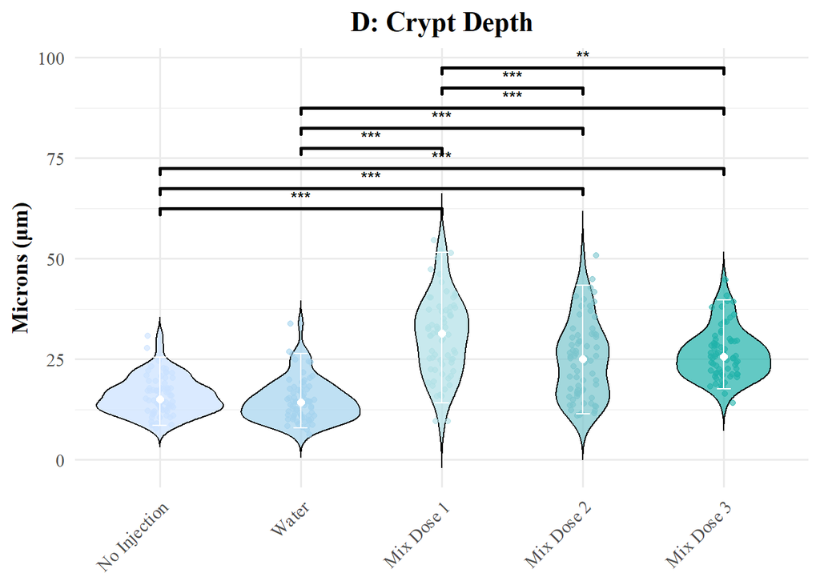

```r
p_crypt <- ggplot(mix_histo, aes(x = treatment, y = crypt_depth, fill = treatment)) +
  # full violin
  geom_violin(trim = FALSE, alpha = 0.7, color = "black") +
  # overlay individual points
  geom_jitter(aes(color = treatment),
              width = 0.1, size = 1.5, alpha = 0.6) +
  # optional: show median + IQR
  stat_summary(fun = median, geom = "point",
               size = 2, color = "white") +
  stat_summary(fun.data = median_hilow, geom = "errorbar",
               width = 0.1, color = "white") +
  # apply your custom palette
  scale_fill_manual(values = treatment_colors) +
  scale_color_manual(values = treatment_colors) +
  # minimal theme + Times New Roman
  theme_minimal(base_size = 14) +
  theme(
    text            = element_text(family = "Times New Roman"),
    axis.text.x     = element_text(angle = 45, hjust = 1),
    plot.title      = element_text(face = "bold", hjust = 0.5),
    axis.title      = element_text(face = "bold"),
    legend.position = "none"
  ) +
  labs(
    title = "D: Crypt Depth",
    x     = NULL,
    y     = "Microns (μm)"
  ) +
  # Add p-value annotations with larger and spaced lines
  geom_signif(
    comparisons = list(
      c("No Injection", "Mix Dose 1"),
      c("No Injection", "Mix Dose 2"),
      c("No Injection", "Mix Dose 3"),
      c("Water", "Mix Dose 1"),
      c("Water", "Mix Dose 2"),
      c("Water", "Mix Dose 3"),
      c("Mix Dose 1", "Mix Dose 2"),
      c("Mix Dose 1", "Mix Dose 3")),  # Define treatment pairs
    map_signif_level = TRUE,  # Automatically adds p-values
    size = 1,  # Increase the size of the lines for better visibility
    y_position = c(60, 65, 70, 75, 80, 85, 90, 95)  # Adjust this to position lines further apart
  )

# Show the updated plot
p_crypt
```

### Summary Crypt Depth

## 5. VH:CD Ratio Graph

```r
mix_histo <-
  mix_histo %>%
  mutate(
    vh_cd = villis_height / crypt_depth
  )

head(mix_histo$vh_cd)
```

```
## [1] 24.978486 16.200526 21.984105 24.534928  8.192133 26.345525
```

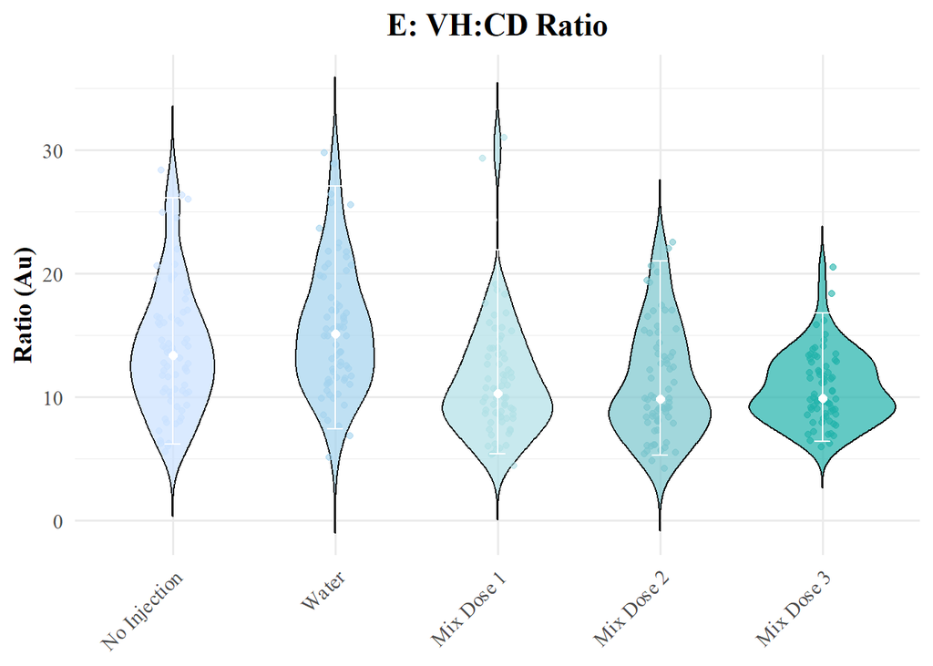

```r
vh_cd <- ggplot(mix_histo, aes(x = treatment, y = vh_cd, fill = treatment)) +
  # full violin
  geom_violin(trim = FALSE, alpha = 0.7, color = "black") +
  # overlay individual points
  geom_jitter(aes(color = treatment),
              width = 0.1, size = 1.5, alpha = 0.6) +
  # optional: show median + IQR
  stat_summary(fun = median, geom = "point",
               size = 2, color = "white") +
  stat_summary(fun.data = median_hilow, geom = "errorbar",
               width = 0.1, color = "white") +
  # apply your custom palette
  scale_fill_manual(values = treatment_colors) +
  scale_color_manual(values = treatment_colors) +
  # minimal theme + Times New Roman
  theme_minimal(base_size = 14) +
  theme(
    text            = element_text(family = "Times New Roman"),
    axis.text.x     = element_text(angle = 45, hjust = 1),
    plot.title      = element_text(face = "bold", hjust = 0.5),
    axis.title      = element_text(face = "bold"),
    legend.position = "none"
  ) +
  labs(
    title = "E: VH:CD Ratio",
    x     = NULL,
    y     = "Ratio (Au)"
  )

vh_cd
```

```r
#model
model_ratio <- lmer(vh_cd ~ treatment + (1|biological_rep), data = mix_histo)
summary(model_ratio)
```

```
## Linear mixed model fit by REML. t-tests use Satterthwaite's method [
## lmerModLmerTest]
## Formula: vh_cd ~ treatment + (1 | biological_rep)
##    Data: mix_histo
##
## REML criterion at convergence: 2056
##
## Scaled residuals:
##     Min      1Q  Median      3Q     Max
## -2.3162 -0.6685 -0.1899  0.5162  4.2010
##
## Random effects:
##  Groups         Name        Variance Std.Dev.
##  biological_rep (Intercept)  0.3033  0.5507
##  Residual                   21.1283  4.5966
## Number of obs: 350, groups:  biological_rep, 7
##
## Fixed effects:
##                     Estimate Std. Error       df t value Pr(>|t|)
## (Intercept)          13.8848     0.5875  60.6601  23.634  < 2e-16 ***
## treatmentWater        1.6769     0.7770 339.0000   2.158 0.031603 *
## treatmentMix Dose 1  -2.5335     0.7770 339.0000  -3.261 0.001224 **
## treatmentMix Dose 2  -2.7139     0.7770 339.0000  -3.493 0.000541 ***
## treatmentMix Dose 3  -3.1718     0.7770 339.0000  -4.082 5.57e-05 ***
## ---
## Signif. codes:  0 '***' 0.001 '**' 0.01 '*' 0.05 '.' 0.1 ' ' 1
##
## Correlation of Fixed Effects:
##             (Intr) trtmnW trtMD1 trtMD2
## treatmntWtr -0.661
## trtmntMxDs1 -0.661  0.500
## trtmntMxDs2 -0.661  0.500  0.500
## trtmntMxDs3 -0.661  0.500  0.500  0.500
```

```r
#post hoc
post_hoc_ratio <- emmeans(model_ratio, pairwise ~ treatment)
summary(post_hoc_ratio)
```

```
## $emmeans
##  treatment    emmean    SE   df lower.CL upper.CL
##  No Injection   13.9 0.588 60.7    12.71     15.1
##  Water          15.6 0.588 60.7    14.39     16.7
##  Mix Dose 1     11.4 0.588 60.7    10.18     12.5
##  Mix Dose 2     11.2 0.588 60.7    10.00     12.3
##  Mix Dose 3     10.7 0.588 60.7     9.54     11.9
##
## Degrees-of-freedom method: kenward-roger
## Confidence level used: 0.95
##
## $contrasts
##  contrast                  estimate    SE  df t.ratio p.value
##  No Injection - Water        -1.677 0.777 339  -2.158  0.1983
##  No Injection - Mix Dose 1    2.533 0.777 339   3.261  0.0107
##  No Injection - Mix Dose 2    2.714 0.777 339   3.493  0.0049
##  No Injection - Mix Dose 3    3.172 0.777 339   4.082  0.0005
##  Water - Mix Dose 1           4.210 0.777 339   5.419  <.0001
##  Water - Mix Dose 2           4.391 0.777 339   5.651  <.0001
##  Water - Mix Dose 3           4.849 0.777 339   6.241  <.0001
##  Mix Dose 1 - Mix Dose 2      0.180 0.777 339   0.232  0.9994
##  Mix Dose 1 - Mix Dose 3      0.638 0.777 339   0.822  0.9239
##  Mix Dose 2 - Mix Dose 3      0.458 0.777 339   0.589  0.9766
##
## Degrees-of-freedom method: kenward-roger
## P value adjustment: tukey method for comparing a family of 5 estimates
```

```r
# Extract p-values for the pairwise comparisons
p_ratio <- as.data.frame(post_hoc_ratio$contrasts)
p_ratio
```

```
##  contrast                   estimate        SE  df t.ratio p.value
##  No Injection - Water      -1.676943 0.7769597 339  -2.158  0.1983
##  No Injection - Mix Dose 1  2.533452 0.7769597 339   3.261  0.0107
##  No Injection - Mix Dose 2  2.713912 0.7769597 339   3.493  0.0049
##  No Injection - Mix Dose 3  3.171761 0.7769597 339   4.082  0.0005
##  Water - Mix Dose 1         4.210395 0.7769597 339   5.419  <.0001
##  Water - Mix Dose 2         4.390854 0.7769597 339   5.651  <.0001
##  Water - Mix Dose 3         4.848703 0.7769597 339   6.241  <.0001
##  Mix Dose 1 - Mix Dose 2    0.180459 0.7769597 339   0.232  0.9994
##  Mix Dose 1 - Mix Dose 3    0.638308 0.7769597 339   0.822  0.9239
##  Mix Dose 2 - Mix Dose 3    0.457849 0.7769597 339   0.589  0.9766
##
## Degrees-of-freedom method: kenward-roger
## P value adjustment: tukey method for comparing a family of 5 estimates
```

```r
# Filter for significant p-values (adjust the threshold as needed, e.g., p < 0.05)
significant_p_ratio <- p_ratio[p_ratio$p.value < 0.05, ]
significant_p_ratio
```

```
##  contrast                  estimate        SE  df t.ratio p.value
##  No Injection - Mix Dose 1 2.533452 0.7769597 339   3.261  0.0107
##  No Injection - Mix Dose 2 2.713912 0.7769597 339   3.493  0.0049
##  No Injection - Mix Dose 3 3.171761 0.7769597 339   4.082  0.0005
##  Water - Mix Dose 1        4.210395 0.7769597 339   5.419  <.0001
##  Water - Mix Dose 2        4.390854 0.7769597 339   5.651  <.0001
##  Water - Mix Dose 3        4.848703 0.7769597 339   6.241  <.0001
##
## Degrees-of-freedom method: kenward-roger
## P value adjustment: tukey method for comparing a family of 5 estimates
```

### Violin Plot of VH-CD Ratio

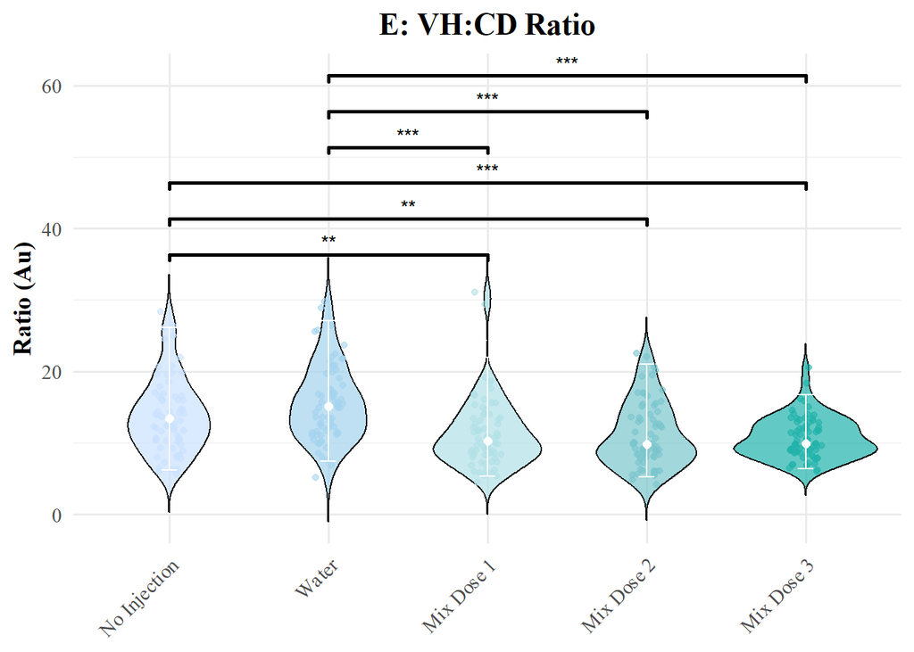

```r
p_ratio <- ggplot(mix_histo, aes(x = treatment, y = vh_cd, fill = treatment)) +
  # full violin
  geom_violin(trim = FALSE, alpha = 0.7, color = "black") +
  # overlay individual points
  geom_jitter(aes(color = treatment),
              width = 0.1, size = 1.5, alpha = 0.6) +
  # optional: show median + IQR
  stat_summary(fun = median, geom = "point",
               size = 2, color = "white") +
  stat_summary(fun.data = median_hilow, geom = "errorbar",
               width = 0.1, color = "white") +
  # apply your custom palette
  scale_fill_manual(values = treatment_colors) +
  scale_color_manual(values = treatment_colors) +
  # minimal theme + Times New Roman
  theme_minimal(base_size = 14) +
  theme(
    text            = element_text(family = "Times New Roman"),
    axis.text.x     = element_text(angle = 45, hjust = 1),
    plot.title      = element_text(face = "bold", hjust = 0.5),
    axis.title      = element_text(face = "bold"),
    legend.position = "none"
  ) +
  labs(
    title = "E: VH:CD Ratio",
    x     = NULL,
    y     = "Ratio (Au)"
  ) +
  # Add p-value annotations with larger and spaced lines
  geom_signif(
    comparisons = list(
      c("No Injection", "Mix Dose 1"),
      c("No Injection", "Mix Dose 2"),
      c("No Injection", "Mix Dose 3"),
      c("Water", "Mix Dose 1"),
      c("Water", "Mix Dose 2"),
      c("Water", "Mix Dose 3")),  # Define treatment pairs
    map_signif_level = TRUE,  # Automatically adds p-values
    size = 1,  # Increase the size of the lines for better visibility
    y_position = c(35, 40, 45, 50, 55, 60)  # Adjust this to position lines further apart
  )

# Show the updated plot
p_ratio
```

### Summary Villus to Crypt Ratio

## 6. Goblet Cell Counts

### Plot Raw values

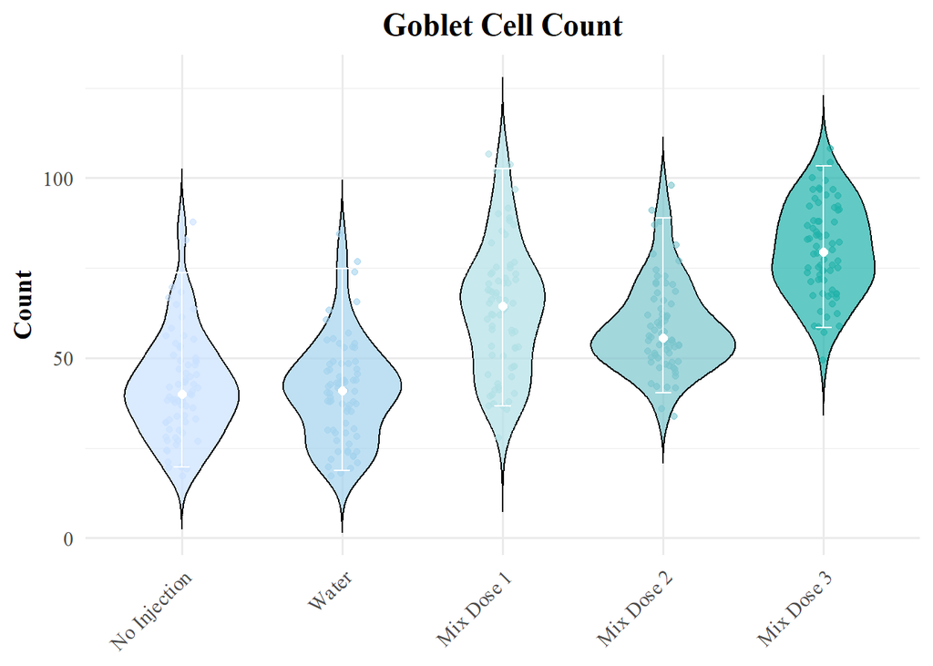

```r
goblet <- ggplot(mix_histo, aes(x = treatment, y = goblet_count, fill = treatment)) +
  # full violin
  geom_violin(trim = FALSE, alpha = 0.7, color = "black") +
  # overlay individual points
  geom_jitter(aes(color = treatment),
              width = 0.1, size = 1.5, alpha = 0.6) +
  # optional: show median + IQR
  stat_summary(fun = median, geom = "point",
               size = 2, color = "white") +
  stat_summary(fun.data = median_hilow, geom = "errorbar",
               width = 0.1, color = "white") +
  # apply your custom palette
  scale_fill_manual(values = treatment_colors) +
  scale_color_manual(values = treatment_colors) +
  # minimal theme + Times New Roman
  theme_minimal(base_size = 14) +
  theme(
    text            = element_text(family = "Times New Roman"),
    axis.text.x     = element_text(angle = 45, hjust = 1),
    plot.title      = element_text(face = "bold", hjust = 0.5),
    axis.title      = element_text(face = "bold"),
    legend.position = "none"
  ) +
  labs(
    title = "Goblet Cell Count",
    x     = NULL,
    y     = "Count"
  )

goblet
```

### Linear Mixed Model Goblet

```r
#model
model_goblet <- lmer(goblet_count ~ treatment + (1|biological_rep), data = mix_histo)
summary(model_goblet)
```

```
## Linear mixed model fit by REML. t-tests use Satterthwaite's method [
## lmerModLmerTest]
## Formula: goblet_count ~ treatment + (1 | biological_rep)
##    Data: mix_histo
##
## REML criterion at convergence: 2849
##
## Scaled residuals:
##     Min      1Q  Median      3Q     Max
## -2.4818 -0.7350 -0.0148  0.5608  3.1927
##
## Random effects:
##  Groups         Name        Variance Std.Dev.
##  biological_rep (Intercept)   6.686   2.586
##  Residual                   208.920  14.454
## Number of obs: 350, groups:  biological_rep, 7
##
## Fixed effects:
##                     Estimate Std. Error      df t value Pr(>|t|)
## (Intercept)           42.029      1.985  37.108  21.175  < 2e-16 ***
## treatmentWater        -1.257      2.443 339.000  -0.515    0.607
## treatmentMix Dose 1   21.343      2.443 339.000   8.736  < 2e-16 ***
## treatmentMix Dose 2   16.700      2.443 339.000   6.835 3.81e-11 ***
## treatmentMix Dose 3   37.900      2.443 339.000  15.513  < 2e-16 ***
## ---
## Signif. codes:  0 '***' 0.001 '**' 0.01 '*' 0.05 '.' 0.1 ' ' 1
##
## Correlation of Fixed Effects:
##             (Intr) trtmnW trtMD1 trtMD2
## treatmntWtr -0.615
## trtmntMxDs1 -0.615  0.500
## trtmntMxDs2 -0.615  0.500  0.500
## trtmntMxDs3 -0.615  0.500  0.500  0.500
```

```r
#post hoc
post_hoc_goblet <- emmeans(model_goblet, pairwise ~ treatment)
summary(post_hoc_goblet)
```

```
## $emmeans
##  treatment    emmean   SE   df lower.CL upper.CL
##  No Injection   42.0 1.98 37.1     38.0     46.0
##  Water          40.8 1.98 37.1     36.8     44.8
##  Mix Dose 1     63.4 1.98 37.1     59.4     67.4
##  Mix Dose 2     58.7 1.98 37.1     54.7     62.7
##  Mix Dose 3     79.9 1.98 37.1     75.9     83.9
##
## Degrees-of-freedom method: kenward-roger
## Confidence level used: 0.95
##
## $contrasts
##  contrast                  estimate   SE  df t.ratio p.value
##  No Injection - Water          1.26 2.44 339   0.515  0.9859
##  No Injection - Mix Dose 1   -21.34 2.44 339  -8.736  <.0001
##  No Injection - Mix Dose 2   -16.70 2.44 339  -6.835  <.0001
##  No Injection - Mix Dose 3   -37.90 2.44 339 -15.513  <.0001
##  Water - Mix Dose 1          -22.60 2.44 339  -9.250  <.0001
##  Water - Mix Dose 2          -17.96 2.44 339  -7.350  <.0001
##  Water - Mix Dose 3          -39.16 2.44 339 -16.027  <.0001
##  Mix Dose 1 - Mix Dose 2       4.64 2.44 339   1.900  0.3191
##  Mix Dose 1 - Mix Dose 3     -16.56 2.44 339  -6.777  <.0001
##  Mix Dose 2 - Mix Dose 3     -21.20 2.44 339  -8.677  <.0001
##
## Degrees-of-freedom method: kenward-roger
## P value adjustment: tukey method for comparing a family of 5 estimates
```

```r
# Extract p-values for the pairwise comparisons
p_goblet <- as.data.frame(post_hoc_goblet$contrasts)
p_goblet
```

```
##  contrast                   estimate       SE  df t.ratio p.value
##  No Injection - Water        1.25714 2.443184 339   0.515  0.9859
##  No Injection - Mix Dose 1 -21.34286 2.443184 339  -8.736  <.0001
##  No Injection - Mix Dose 2 -16.70000 2.443184 339  -6.835  <.0001
##  No Injection - Mix Dose 3 -37.90000 2.443184 339 -15.513  <.0001
##  Water - Mix Dose 1        -22.60000 2.443184 339  -9.250  <.0001
##  Water - Mix Dose 2        -17.95714 2.443184 339  -7.350  <.0001
##  Water - Mix Dose 3        -39.15714 2.443184 339 -16.027  <.0001
##  Mix Dose 1 - Mix Dose 2     4.64286 2.443184 339   1.900  0.3191
##  Mix Dose 1 - Mix Dose 3   -16.55714 2.443184 339  -6.777  <.0001
##  Mix Dose 2 - Mix Dose 3   -21.20000 2.443184 339  -8.677  <.0001
##
## Degrees-of-freedom method: kenward-roger
## P value adjustment: tukey method for comparing a family of 5 estimates
```

```r
# Filter for significant p-values (adjust the threshold as needed, e.g., p < 0.05)
significant_p_goblet <- p_goblet[p_goblet$p.value < 0.05, ]
significant_p_goblet
```

```
##  contrast                   estimate       SE  df t.ratio p.value
##  No Injection - Mix Dose 1 -21.34286 2.443184 339  -8.736  <.0001
##  No Injection - Mix Dose 2 -16.70000 2.443184 339  -6.835  <.0001
##  No Injection - Mix Dose 3 -37.90000 2.443184 339 -15.513  <.0001
##  Water - Mix Dose 1        -22.60000 2.443184 339  -9.250  <.0001
##  Water - Mix Dose 2        -17.95714 2.443184 339  -7.350  <.0001
##  Water - Mix Dose 3        -39.15714 2.443184 339 -16.027  <.0001
##  Mix Dose 1 - Mix Dose 3   -16.55714 2.443184 339  -6.777  <.0001
##  Mix Dose 2 - Mix Dose 3   -21.20000 2.443184 339  -8.677  <.0001
##
## Degrees-of-freedom method: kenward-roger
## P value adjustment: tukey method for comparing a family of 5 estimates
```

### Violin Plot Goblet Cells with Significance

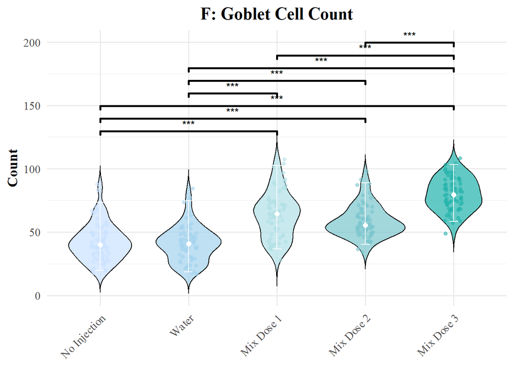

```r
p_goblet <- ggplot(mix_histo, aes(x = treatment, y = goblet_count, fill = treatment)) +
  # full violin
  geom_violin(trim = FALSE, alpha = 0.7, color = "black") +
  # overlay individual points
  geom_jitter(aes(color = treatment),
              width = 0.1, size = 1.5, alpha = 0.6) +
  # optional: show median + IQR
  stat_summary(fun = median, geom = "point",
               size = 2, color = "white") +
  stat_summary(fun.data = median_hilow, geom = "errorbar",
               width = 0.1, color = "white") +
  # apply your custom palette
  scale_fill_manual(values = treatment_colors) +
  scale_color_manual(values = treatment_colors) +
  # minimal theme + Times New Roman
  theme_minimal(base_size = 14) +
  theme(
    text            = element_text(family = "Times New Roman"),
    axis.text.x     = element_text(angle = 45, hjust = 1),
    plot.title      = element_text(face = "bold", hjust = 0.5),
    axis.title      = element_text(face = "bold"),
    legend.position = "none"
  ) +
  labs(
    title = "F: Goblet Cell Count",
    x     = NULL,
    y     = "Count"
  ) +
  # Add p-value annotations with larger and spaced lines
  geom_signif(
    comparisons = list(
      c("No Injection", "Mix Dose 1"),
      c("No Injection", "Mix Dose 2"),
      c("No Injection", "Mix Dose 3"),
      c("Water", "Mix Dose 1"),
      c("Water", "Mix Dose 2"),
      c("Water", "Mix Dose 3"),
      c("Mix Dose 1", "Mix Dose 3"),
      c("Mix Dose 2", "Mix Dose 3")),  # Define treatment pairs
    map_signif_level = TRUE,  # Automatically adds p-values
    size = 1,  # Increase the size of the lines for better visibility
    y_position = c(125, 135, 145, 155, 165, 175, 185, 195)  # Adjust this to position lines further apart
  )

# Show the updated plot
p_goblet
```

## 7. Making a publication ready figure

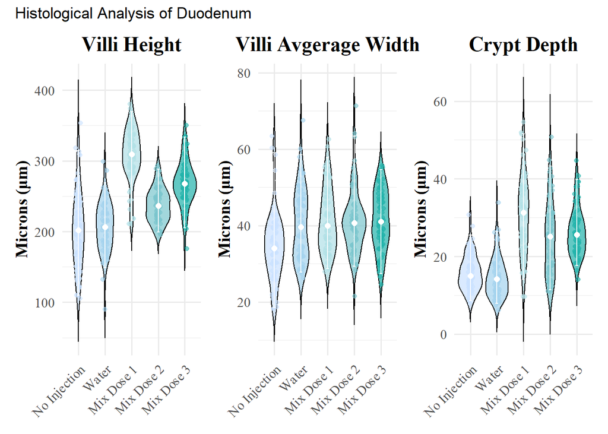

```r
# just figures no significance
raw <- (height | width | crypt ) +
  plot_annotation(title = "Histological Analysis of Duodenum")

raw
```

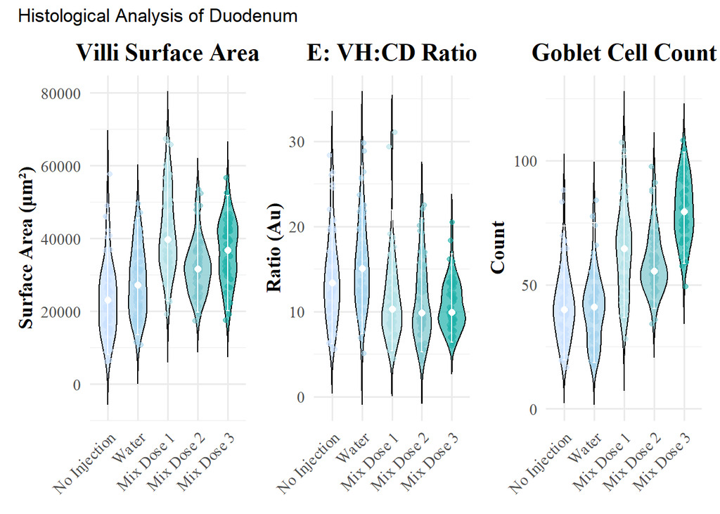

```r
calculated <- (surface_area | vh_cd | goblet) +
  plot_annotation(title = "Histological Analysis of Duodenum")

calculated
```

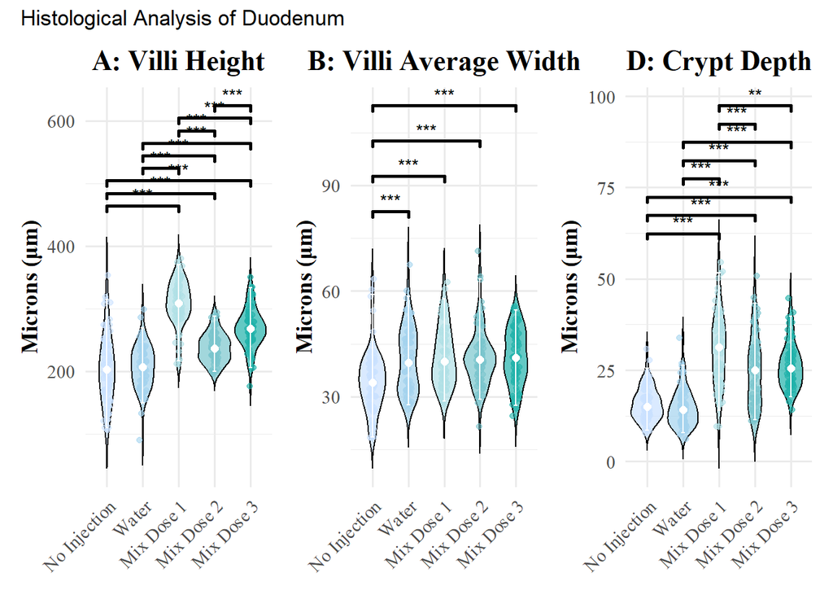

```r
# with p - values

p_raw <- (p_height | p_width | p_crypt ) +
  plot_annotation(title = "Histological Analysis of Duodenum")

p_raw
```

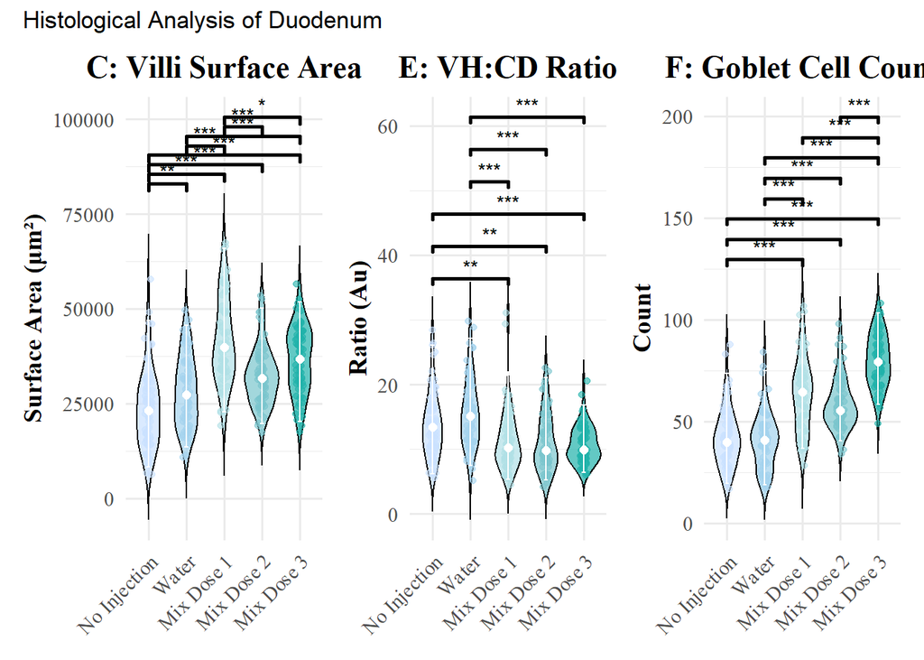

```r
p_calculated <- (p_SA | p_ratio | p_goblet) +
  plot_annotation(title = "Histological Analysis of Duodenum")

p_calculated
```

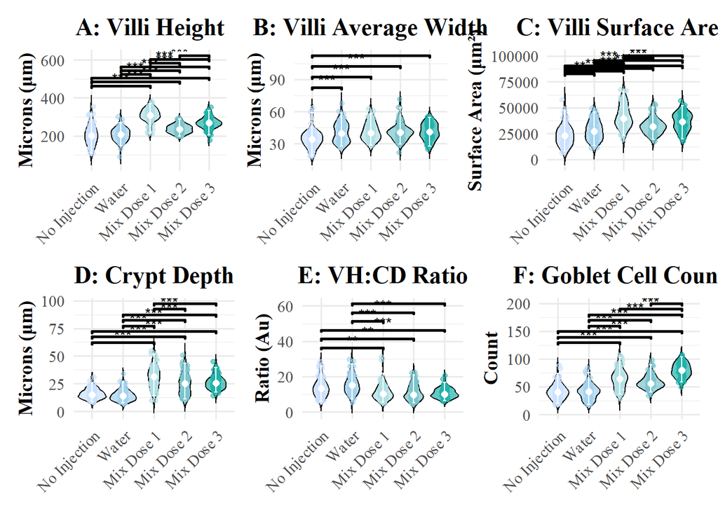

```r
all_p <- (p_height | p_width | p_SA) / (p_crypt | p_ratio | p_goblet)

all_p #this is a master piece if I do say so myself :)
```

```r
ggsave("C:/Users/Chloe/OneDrive - Cornell University/study-1-march25/MIX/Figures/03_DuodenumHistology/all-p-value-plots.png", plot = all_p, width = 14, height = 14, dpi = 600)
```

# Assumptions

```r
# height
# Residuals vs Fitted plot to check linearity
plot(model_height, which = 1) # YAY looks good
```

[output not shown]

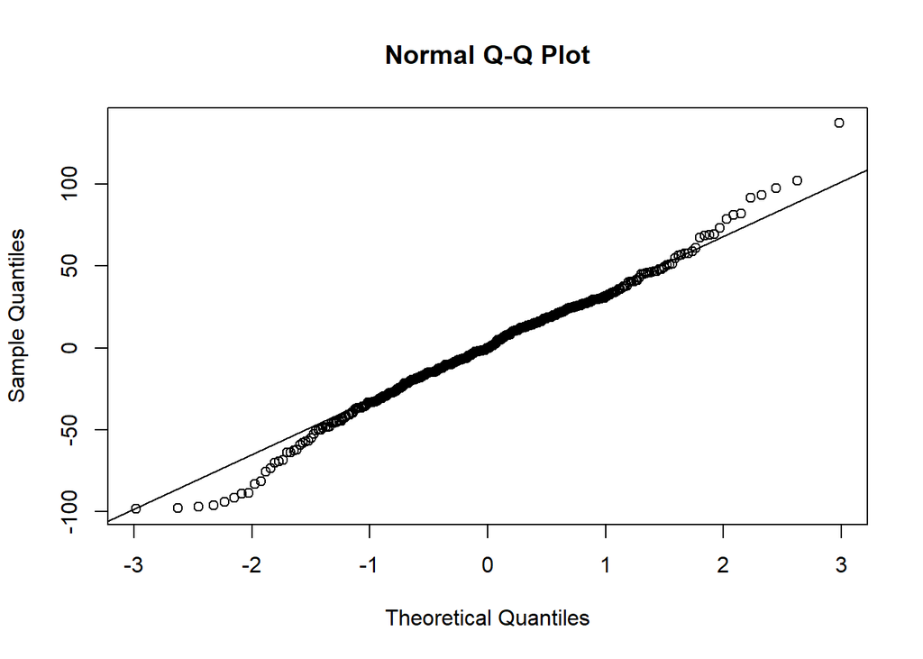

```r
# Q-Q plot to check normality of residuals
qqnorm(resid(model_height))
qqline(resid(model_height)) # there is some deviation at the tails, i think it is ok
```

```r
# Residuals vs Fitted plot to check homoscedasticity
plot(model_height, which = 1)
```

[output not shown]

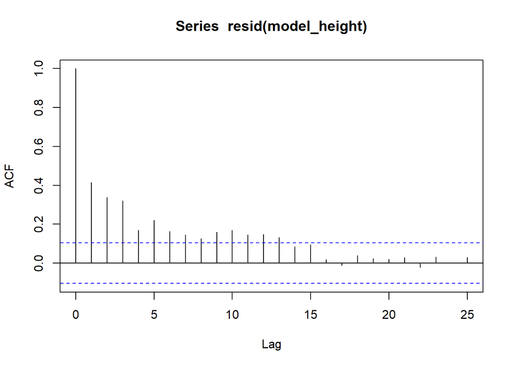

```r
# Check residuals for autocorrelation
acf(resid(model_height)) # there is no pattern for homoscedasticity
```

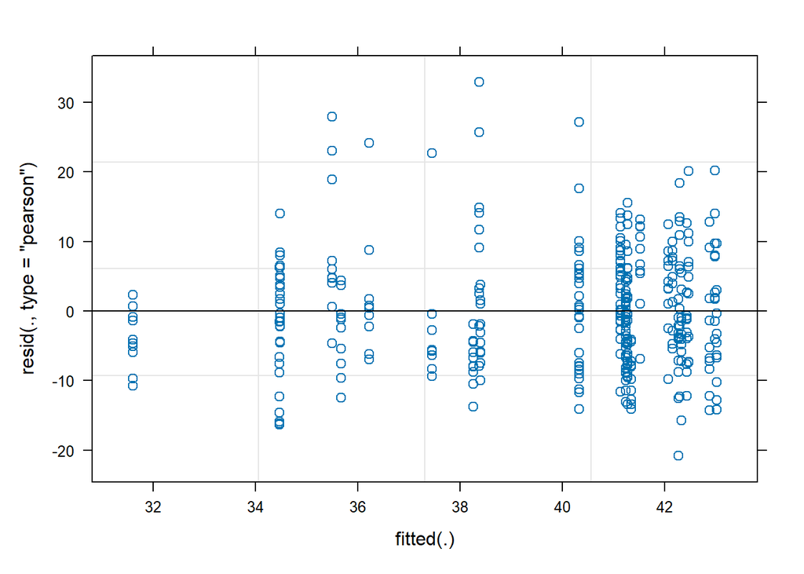

```r
# width

plot(model_width, which = 1) # YAY looks good
```

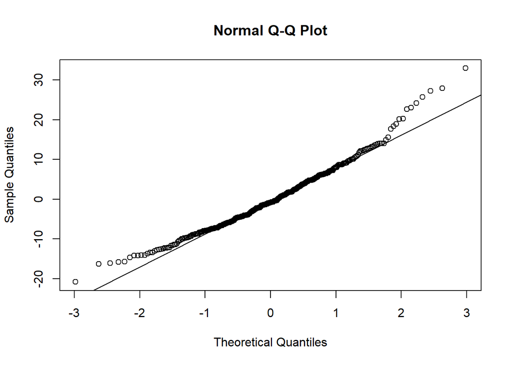

```r
# Q-Q plot to check normality of residuals
qqnorm(resid(model_width))
qqline(resid(model_width)) # there is some deviation at the tails, i think it is ok
```

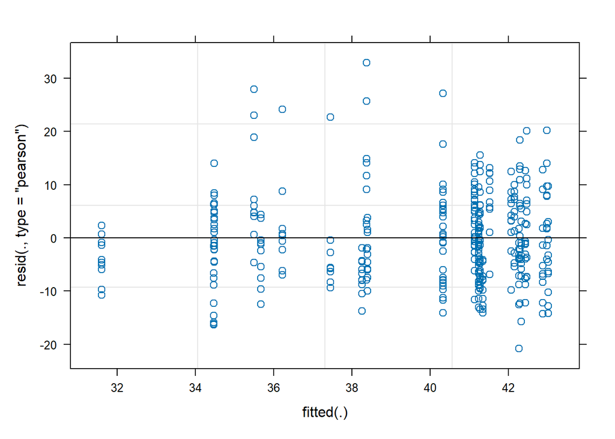

```r
# Residuals vs Fitted plot to check homoscedasticity
plot(model_width, which = 1)
```

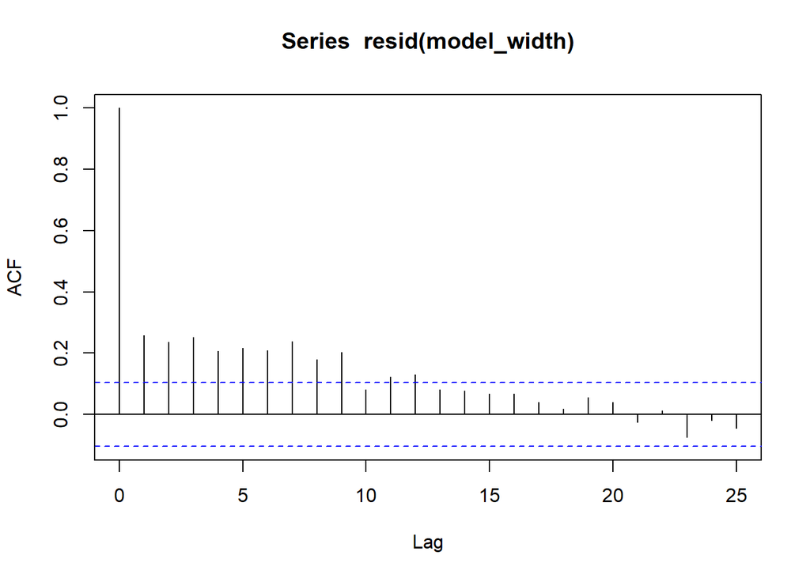

```r
# Check residuals for autocorrelation
acf(resid(model_width)) # there is no pattern for homoscedasticity
```

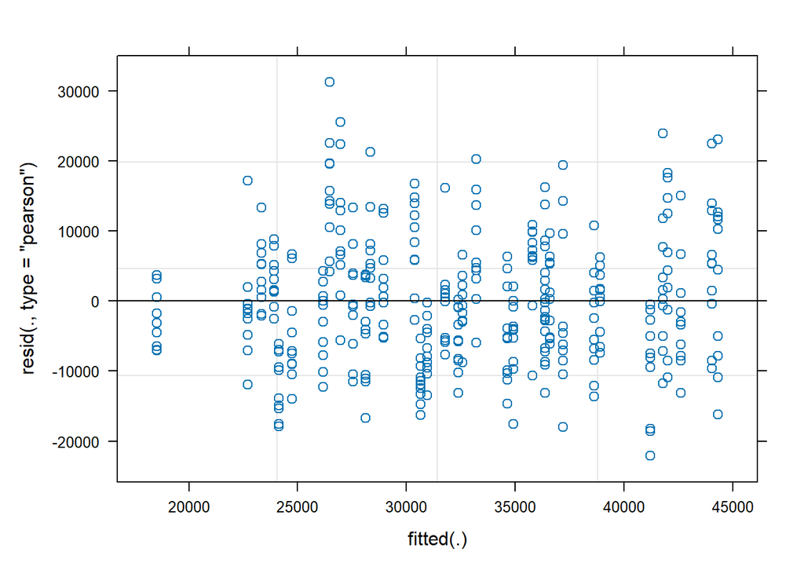

```r
# SA

plot(model_SA, which = 1) # YAY looks good
```

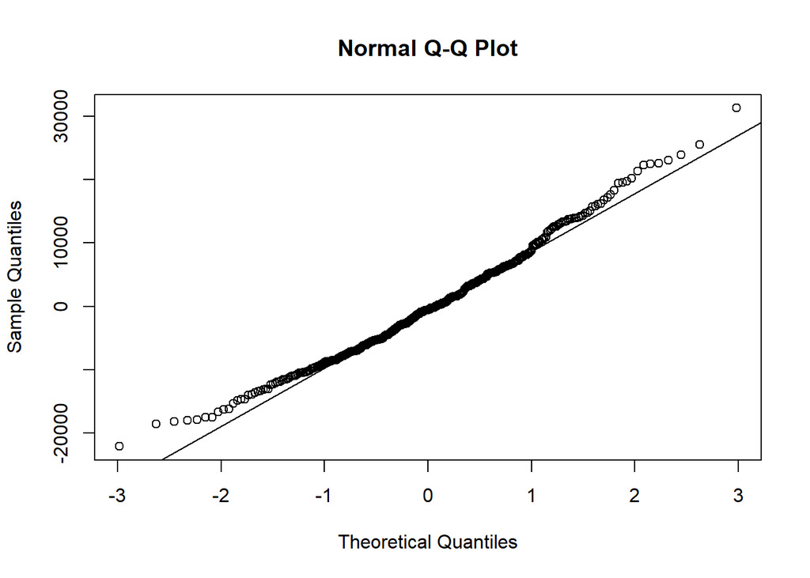

```r
# Q-Q plot to check normality of residuals
qqnorm(resid(model_SA))
qqline(resid(model_SA)) # there is some deviation at the tails, i think it is ok
```

```r
# Residuals vs Fitted plot to check homoscedasticity
plot(model_height, which = 1)
```

[output not shown]

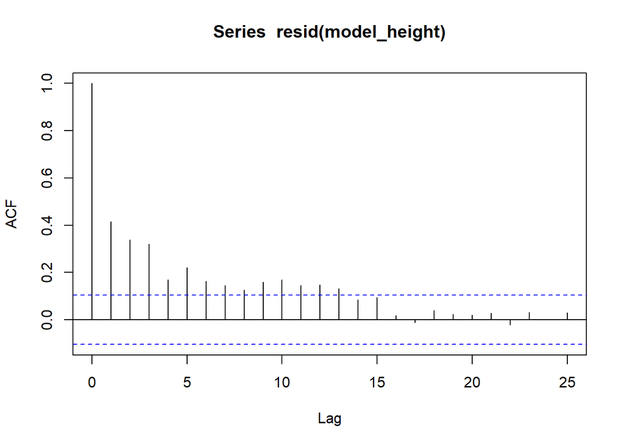

```r
# Check residuals for autocorrelation
acf(resid(model_height)) # there is no pattern for homoscedasticity
```

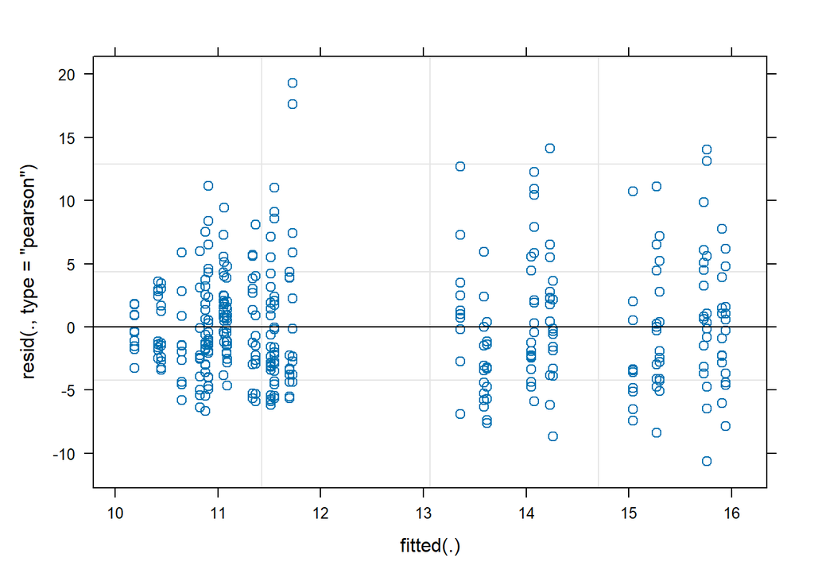

```r
# ratio

plot(model_ratio, which = 1) # YAY looks good
```

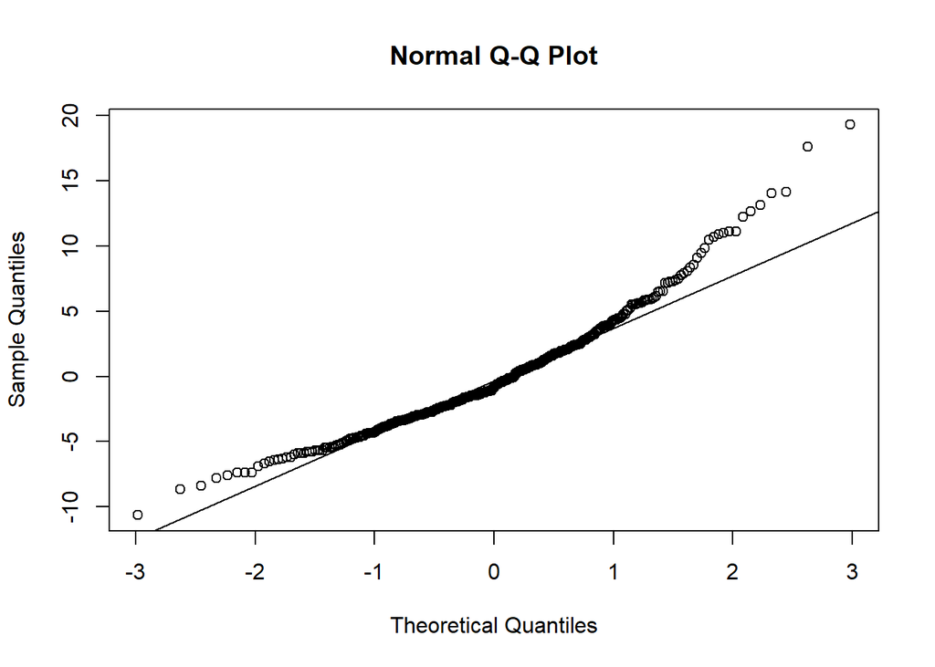

```r
# Q-Q plot to check normality of residuals
qqnorm(resid(model_ratio))
qqline(resid(model_ratio)) # there is some deviation at the tails, i think it is ok
```

```r
# Residuals vs Fitted plot to check homoscedasticity
plot(model_height, which = 1)
```

[output not shown]

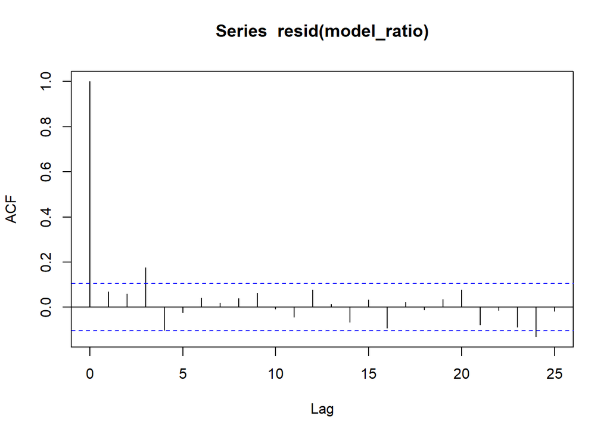

```r
# Check residuals for autocorrelation
acf(resid(model_ratio)) # there is no pattern for homoscedasticity
```